# Flow-Habitat Area Curves

Department of Water Resources Healthy Rivers and Landscapes Team

November 7, 2024

# Introduction

Parties to the Voluntary Agreements have committed to restoring habitat in the Sacramento River watershed (Table 1).

Table 1: Habitat restoration commitments made by Voluntary Agreements parties

| System | Spawning Acres | Rearing Acres | Instream Acres | Floodplain Acres |
| --- | --- | --- | --- | --- |
| Sacramento | 113.5 | 0 | 137.5 | 0 |
| Sutter Bypass, Butte Sink, and Colusa Basin | 0.0 | 0 | 0.0 | 20,000 |
| Feather | 15.0 | 0 | 5.2 | 0 |
| Yuba | 0.0 | 0 | 50.0 | 100 |
| American | 25.0 | 75 | 0.0 | 0 |
| Mokelumne | 0.0 | 0 | 1.0 | 25 |
| Putah | 1.4 | 0 | 0.0 | 0 |
| North Delta Arc and Suisun Marsh | 0.0 | 0 | 0.0 | 5,228 |
| Total | 154.9 | 75 | 193.8 | 25,352 |

Restored sites will be designed and constructed with water depth and velocity criteria over a range of flows that are suitable for target species. Tributary sites will be oriented toward salmonids, while Delta sites will address the habitat needs of a wider range of native fishes (e.g. delta smelt and longfin smelt).

Because of this, habitat accounting in tributaries includes development and/or refinement of flow-habitat area relationships over a range of flows expected at restored sites under the flow commitments associated with the Voluntary Agreements program and resulting hydrographs. This document discusses the flow-habitat area relationships proposed by Voluntary Agreements parties and those proposed by the State Water Resources Control Board (SWRCB) as related to restoration site design, habitat accounting and consistency assessments.

## Documents

There are three documents that address habitat accounting under the Voluntary Agreements:

- The [**SWRCB Scientific Basis Report Supplement**](https://www.waterboards.ca.gov/waterrights/water_issues/programs/bay_delta/docs/2023/staff-report/app-g2.pdf) documents the science supporting the proposed provisions included in the Voluntary Agreements and was developed by SWRCB staff with the support of Department of Water Resources (DWR) and California Department of Fish and Wildlife (CDFW) staff
- The [**Draft Voluntary Agreements Strategic Plan Appendix F**](https://resources.ca.gov/-/media/CNRA-Website/Files/Initiatives/Support-Healthy-Rivers-and-Landscape/AppF_HabitatAccountingProtocol.pdf) documents a method for non-flow measure (habitat restoration) accounting proposed by the parties to the Voluntary Agreements
- The [**SWRCB Draft Program of Implementation**](https://waterboards.ca.gov/waterrights/water_issues/programs/bay_delta/docs/2024/drft-sacdelta-bdplan-updates.pdf) provides pathways for implementing that Bay-Delta Water Quality Control Plan that incorporate the Voluntary Agreements with amendments recommended by SWRCB staff

# SWRCB Scientific Basis Report Supplement

In the Final Scientific Basis Report Supplement, SWRCB staff authors detail an approach for estimating and tracking suitable habitat areas for salmonid spawning and rearing by linking flow rates to habitat suitability. To develop appropriate restoration depth and flow criteria, FlowWest staff and experts compiled a dataset of flow-to-habitat relationships for Central Valley watersheds, drawn from published studies, and attempted to validate the dataset using on-the-ground observations produced by experts working in each watershed (Figure 1).

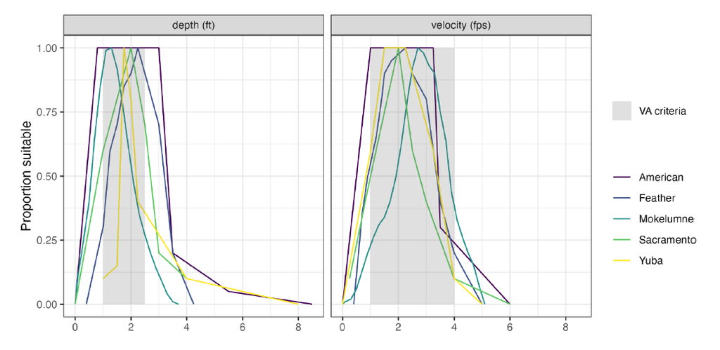

Figure 1: Spawning habitat suitability criteria

Habitat suitability is measured as weighted usable area per channel length. This index, derived from a combination of hydrodynamic modeling and physical habitat modeling, assess the impact of depth and velocity on habitat conditions. The weighted usable area is calculated using depth and velocity criteria specific to each tributary, which are based on observation of fish presence in different conditions. The resulting flow-to-suitable-area relationships provide time-series data that estimate total suitable habitat as a function of modeled hydrology for each tributary or, in some cases, tributary reach.

For each restoration site, flow-habitat curves indicate the potential habitat area that meets the suitability standards at different flow rates. This allows project planners to estimate how much suitable habitat will be available at the design flow (the expected flow rate during salmonid life stages). Project outcomes are evaluated based on whether the added habitat area remains within suitable criteria across expected flow ranges.

Lastly, it is expected that for rearing habitat, cover features constitute a minimum of 20% of the total habitat area.

## Draft Voluntary Agreements Strategic Plan Appendix F

Habitat accounting for tributary spawning, in-channel rearing, and tributary floodplain rearing habitat enhancement measures accounts for the acreage of implemented habitat enhancement measures based on design criteria for specific projects. Design criteria include water depth and water velocity, as well as substrate for spawning measures, and cover for tributary in-channel and tributary floodplain rearing measures.

Habitat accounting is a site-specific assessment that will be conducted at the completion of each individual project’s construction and will serve as an incremental accounting step for whether Voluntary Agreements parties have met their non-flow habitat total acreage commitments (Table 1). Site-specific assessments must quantify the areas within a project’s boundary that conform with specific design criteria at design flows, the range of flows over which a habitat enhancement project is designed to create habitat. A project’s design flows may be informed by habitat objectives, habitat features, biological objectives, and riverine processes. Flows at which pre-project and as-built conditions are compared must be identical.

The design criteria will incorporate water depth and velocity, which includes development or refinement of habitat-flow relationships over a range of flows reflective of those assumed in the SWRCB Scientific Basis Report Supplement for each tributary. Development of new or revised habitat-flow relationships will form the basis of a consistency assessment that will compare the availability of habitat over the range of applicable flows realized through implementation with the assumptions made in the SWRCB Scientific Basis Report Supplement.

### Pre-project characterization

To characterize projects before construction, the project sponsor will:

1. Characterize pre-project physical conditions, including topography, substrate, and cover.
2. Construct a digital elevation model of the project footprint and create  
   substrate and cover rasters.
3. Apply two-dimensional hydraulic models to calculate water depths and velocities for each computational pixel in the project footprint at each modeled flow within the range of design flows.
4. Determine where design criteria (water depth and velocity) are met at each modeled flow within the range of design flows for each computational pixel in the project footprint using hydraulic (e.g. water depth and velocity) and non-hydraulic (e.g. substrate) criteria as binary functions. If a computational pixel corresponds with the hydraulic and applicable non-hydraulic  
   criteria, the pixel is considered to meet design criteria.
5. Sum the area of all computational pixels in the project’s footprint that meet design criteria to identify the explicit area (acres) of habitat that meet design criteria at each modeled flow in the range of design flows.

See Figure 2 for a graphical illustration of pre-project characterization.

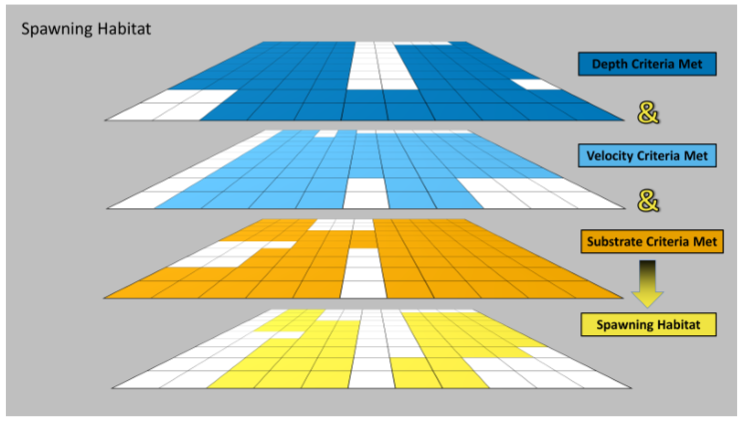

Figure 2: Spawning habitat pre-project characterization

### As-built characterization

The process for characterizing projects once built will be the same pre-project characterization, including new characterization of physical conditions and the development of necessary rasters.

### Pre-project and as-built differencing

Once the as-built project has been characterized, the pre-project and as-built characterizations will be compared to determine the pixels for which additional habitat has been constructed (i.e. design criteria are newly met) and the pixels for which habitat has been lost (i.e. design criteria were met before the project but are no longer met in the as-built project) (Figure 3). This comparison will be conducted for all modeled design flows, starting with the lowest design flow. The pre-project and as-built comparison will focus exclusively on areas newly wetted by each increase in design flow.

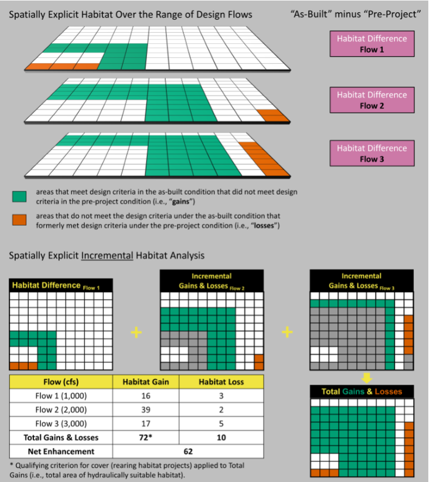

Figure 3: Spawning habitat pre-project and as-built comparison

For each tributary rearing habitat enhancement, an area meeting hydraulic criteria is counted as rearing habitat only if at least 20% of its area includes cover features with a habitat suitability index of at least 0.5. To determine the extent of cover, cover features within the project footprint should be mapped and then digitized to produce a spatial file (e.g. shapefile) (Figure 4). Because juvenile salmonids are typically found within three ft of cover elements (see e.g. Moniz and Pasternack 2019 and Hardy et al. 2006), each suitable non-cobble cover feature element (e.g. boulders or large woody debris) should be buffered by three feet in all directions. Then, the cover spatial file should be converted to a raster, where each raster pixel with a centroid that falls within the buffered cover spatial file is assigned that cover type.

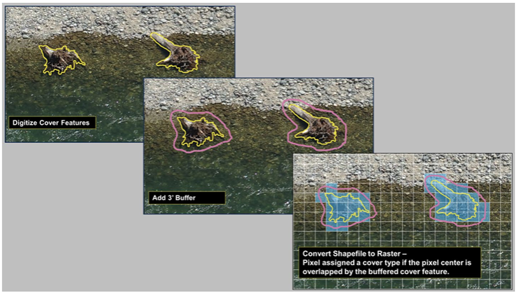

Figure 4: Developing a cover raster

Cover will be evaluated at project completion in accordance with full implementation of the project design (e.g. vegetation at maturity). Estimates of riparian vegetation area should be species-specific estimates of mature canopy size.

If less than 20% of the final, as-built rearing project area has cover, quantified using this methodology, no newly constructed habitat is counted.

## SWRCB Draft Program of Implementation

The SWRCB Draft Program of Implementation for the Bay-Delta Water Quality Control Plan specific water depth and velocity design criteria for spawning habitat, instream rearing habitat, and tributary floodplain rearing habitat (Table 2).

Table 2: Tributary habitat design criteria

[output not shown]

The pre-project and as-built characterization steps in the Draft Program of Implementation are functionally equivalent to those in Appendix F, with the notable exception that the Draft Program of Implementation specifies that the areal extent of a cover feature *should not* be buffered. Additionally, habitat verification must occur to confirm that the acreage of habitat meeting design criteria across a range of flows conforms with or provides equivalent benefits to the flow-habitat relationships provided in the SWRCB Scientific Basis Report Supplement (the “assumed flow-habitat relationships”).

To account for newly constructed habitat, in the final habitat accounting assessment, compare the constructed (as-built) flow-habitat relationship to the flow-habitat relationships used in the SWRCB Scientific Basis Report Supplement:

1. Within each design flow, add the constructed flow-habitat relationships across projects to create an overall constructed flow-habitat relationship for each *habitat type* and *tributary or reach*, matching the spatial scale of the assumed flow-habitat relationship.
2. Compare this constructed flow-habitat relationship to the assumed flow-habitat relationships